# Raghu_606_Project_Proposal

Raghu Ramnath

3/11/2017

```r
require(lubridate)
require(dplyr)
require(tidyr)
require(stringr)
require(RMySQL)
require(doBy)
require(knitr)
```

```r
require(ggplot2)
require(reshape)
knitr::opts_chunk$set(echo = TRUE)
```

### Data Preparation

```r
yr_2013 <- read.csv(file = ("https://raw.githubusercontent.com/raghu74us/606/master/2013_shooter.csv"),sep =",")

#not including the columns that are not needed for analysis.
yr_2013 <- yr_2013[ , c('date', 'killed', 'wounded', 'location')]
     #split state and city based on location
     str(yr_2013)
```

```
## 'data.frame':    363 obs. of  4 variables:
##  $ date    : Factor w/ 210 levels "1/1/13","1/10/13",..: 1 1 1 1 10 11 11 11 2 3 ...
##  $ killed  : int  4 1 0 1 4 5 2 3 3 1 ...
##  $ wounded : int  0 3 4 4 0 0 2 1 2 4 ...
##  $ location: Factor w/ 249 levels "Aguas Buenas, PR",..: 199 87 135 122 9 228 76 50 154 229 ...
```

```r
     head(yr_2013,5)
```

```
##     date killed wounded       location
## 1 1/1/13      4       0 Sacramento, CA
## 2 1/1/13      1       3  Hawthorne, CA
## 3 1/1/13      0       4 McKeesport, PA
## 4 1/1/13      1       4     Lorain, OH
## 5 1/5/13      4       0     Aurora, CO
```

```r
     cit_st <- strsplit( as.character(yr_2013$location), ", " , fixed=TRUE)
     mat  <- matrix(unlist(cit_st), ncol=2, byrow=TRUE)
     df   <- as.data.frame(mat)
     yr_2013_cit_st   <- cbind(yr_2013, df)
     colnames(yr_2013_cit_st) <- c('date', 'killed', 'wounded', 'location', "City", "State")

     #Add month and year based on date.
     yr_2013_cit_st$date <- mdy(yr_2013_cit_st$date)

     str(yr_2013_cit_st)
```

```
## 'data.frame':    363 obs. of  6 variables:
##  $ date    : Date, format: "2013-01-01" "2013-01-01" ...
##  $ killed  : int  4 1 0 1 4 5 2 3 3 1 ...
##  $ wounded : int  0 3 4 4 0 0 2 1 2 4 ...
##  $ location: Factor w/ 249 levels "Aguas Buenas, PR",..: 199 87 135 122 9 228 76 50 154 229 ...
##  $ City    : Factor w/ 244 levels "Aguas Buenas",..: 195 87 131 119 9 223 76 50 150 224 ...
##  $ State   : Factor w/ 49 levels "AL","AZ","CA",..: 3 3 37 34 4 36 28 46 18 1 ...
```

```r
     y1<-year(yr_2013_cit_st$date)
     m1<-as.character(yr_2013_cit_st$date, format="%b")
     d1<-as.character(yr_2013_cit_st$date, format="%d")

     df1  <- cbind(d1,m1,y1)
     colnames(df1)  <- c('day','month','year')

     yr_2013_df2 <- cbind(yr_2013_cit_st , df1)
     #str(yr_2013_df2)

    #summarize by total killed and wounded in each state
     yr_2013_df2_kw <- yr_2013_df2  %>%
        select(year,State,month,killed,wounded) %>%
         filter( str_length(yr_2013_df2$State) == 2) %>%
          group_by(year,State,month )  %>%
           summarise_each(funs(sum) ) %>%
             arrange(year,State,month)

    #summarize by total incidents in each state
        yr_2013_df2_inc <- yr_2013_df2  %>%
        select(year,State,month,killed,wounded) %>%
         filter( str_length(yr_2013_df2$State) == 2) %>%
          group_by(year,State,month )  %>%
            summarise( total_incidents= n() )  %>%
             arrange(year,State,month)

     kable(yr_2013_df2_kw)
```

| year | State | month | killed | wounded |
| --- | --- | --- | --- | --- |
| 2013 | AL | Dec | 6 | 6 |
| 2013 | AL | Jan | 1 | 4 |
| 2013 | AL | Jul | 1 | 7 |
| 2013 | AL | Mar | 3 | 1 |
| 2013 | AL | May | 0 | 4 |
| 2013 | AL | Oct | 4 | 0 |
| 2013 | AZ | Apr | 2 | 4 |
| 2013 | AZ | Jan | 3 | 1 |
| 2013 | AZ | May | 5 | 4 |
| 2013 | AZ | Nov | 5 | 3 |
| 2013 | AZ | Oct | 5 | 4 |
| 2013 | CA | Apr | 3 | 13 |
| 2013 | CA | Aug | 3 | 12 |
| 2013 | CA | Dec | 4 | 0 |
| 2013 | CA | Feb | 12 | 25 |
| 2013 | CA | Jan | 5 | 7 |
| 2013 | CA | Jul | 6 | 15 |
| 2013 | CA | Jun | 10 | 12 |
| 2013 | CA | Mar | 7 | 23 |
| 2013 | CA | May | 6 | 16 |
| 2013 | CA | Nov | 2 | 23 |
| 2013 | CA | Oct | 4 | 35 |
| 2013 | CA | Sep | 6 | 19 |
| 2013 | CO | Feb | 3 | 1 |
| 2013 | CO | Jan | 4 | 0 |
| 2013 | CO | Jun | 0 | 4 |
| 2013 | CO | Sep | 0 | 5 |
| 2013 | CT | Dec | 4 | 0 |
| 2013 | CT | Jul | 0 | 4 |
| 2013 | CT | Oct | 1 | 5 |

[output cut: 175 more lines]

```r
     kable(yr_2013_df2_inc)
```

| year | State | month | total_incidents |
| --- | --- | --- | --- |
| 2013 | AL | Dec | 2 |
| 2013 | AL | Jan | 1 |
| 2013 | AL | Jul | 2 |
| 2013 | AL | Mar | 1 |
| 2013 | AL | May | 1 |
| 2013 | AL | Oct | 1 |
| 2013 | AZ | Apr | 1 |
| 2013 | AZ | Jan | 1 |
| 2013 | AZ | May | 2 |
| 2013 | AZ | Nov | 2 |
| 2013 | AZ | Oct | 2 |
| 2013 | CA | Apr | 4 |
| 2013 | CA | Aug | 3 |
| 2013 | CA | Dec | 1 |
| 2013 | CA | Feb | 7 |
| 2013 | CA | Jan | 3 |
| 2013 | CA | Jul | 5 |
| 2013 | CA | Jun | 4 |
| 2013 | CA | Mar | 6 |
| 2013 | CA | May | 5 |
| 2013 | CA | Nov | 5 |
| 2013 | CA | Oct | 5 |
| 2013 | CA | Sep | 5 |
| 2013 | CO | Feb | 1 |
| 2013 | CO | Jan | 1 |
| 2013 | CO | Jun | 1 |
| 2013 | CO | Sep | 1 |
| 2013 | CT | Dec | 1 |
| 2013 | CT | Jul | 1 |
| 2013 | CT | Oct | 1 |

[output cut: 175 more lines]

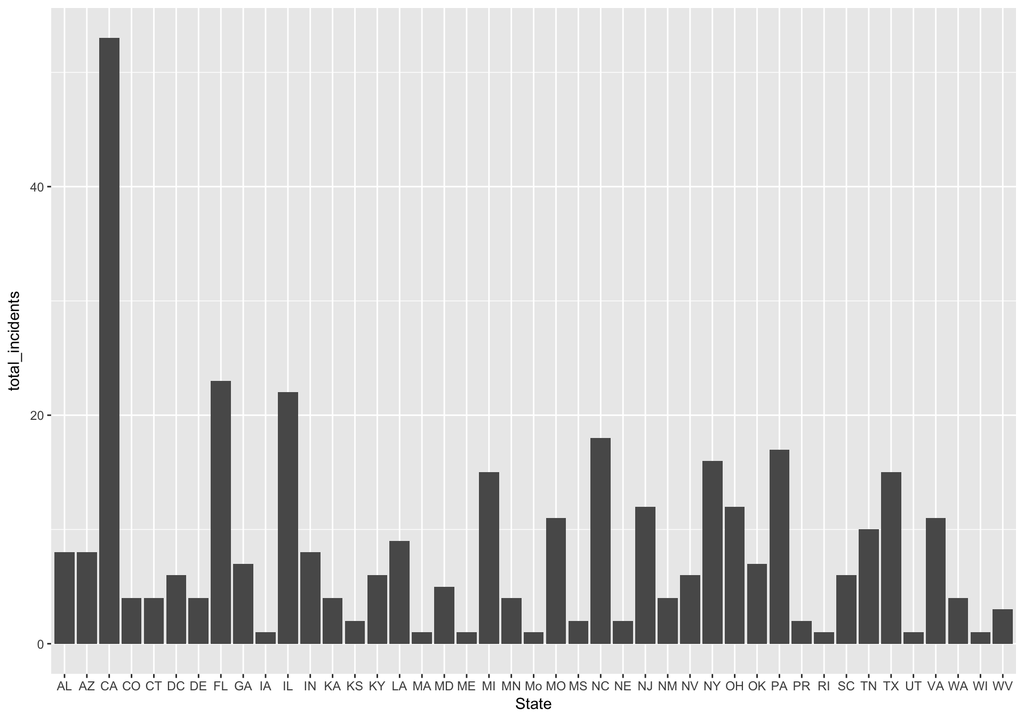

```r
# Total Incidents by State:
ggplot(data = yr_2013_df2_inc,
  aes(State, total_incidents)) +
  stat_summary(fun.y = sum, # adds up all observations for the State
    geom = "bar")
```

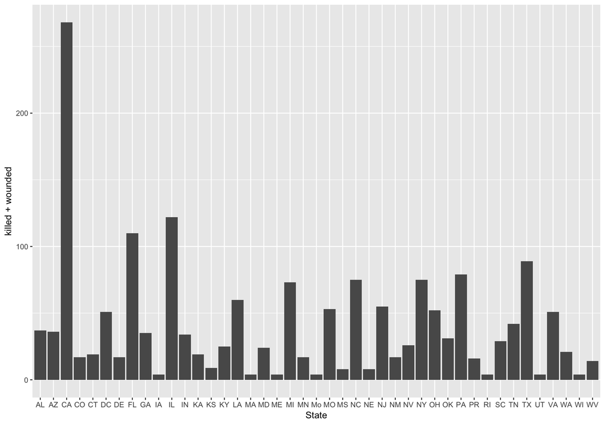

```r
# Total killed + wounded  by State:
ggplot(data = yr_2013_df2_kw,
  aes(State, killed + wounded )) +
  stat_summary(fun.y = sum, # adds up all observations for the State
    geom = "bar")
```

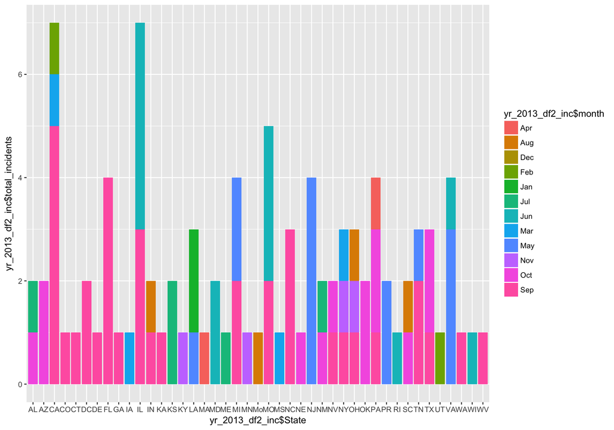

```r
# Total incidents by state and month
ggplot(data = yr_2013_df2_inc, aes(x = yr_2013_df2_inc$State, y = yr_2013_df2_inc$total_incidents, fill = yr_2013_df2_inc$month)) +
       stat_summary(fun.y = sum, # adds up all observations for the State
           geom = "bar")
```

```r
knitr::opts_chunk$set(echo = TRUE)
```

### Research question

Is mass shooting predictable in a State based on the prior data ?. I will be using 2013 data for analysis.

## Data collection

### Describe the method of data collection.

Data is available in Buzfeed News. There are data files for each year from 2013 to 2015.

## Type of study

### What type of study is this (observational/experiment)?

This study is observational.

## Data Source

Data is available under the below link. https://github.com/BuzzFeedNews/2015-12-mass-shooting-intervals/tree/master/data

## Response

### What is the response variable, and what type is it (numerical/categorical)?

Response variable is the number of incidents in a month in a city, State. It is numerical.

## Explanatory

### What is the explanatory variable, and what type is it (numerical/categorival)?

Number of incidents each month. Has the incidents happened each month what is the count of it. This need to be done for atleast 3 years to decide which city has highest incident and the reoccurrence chances each month.

### Relevant summary statistics

Provide summary statistics relevant to your research question. For example, if you’re comparing means across groups provide means, SDs, sample sizes of each group. This step requires the use of R, hence a code chunk is provided below. Insert more code chunks as needed.

```r
summary(yr_2013_df2_inc$total_incidents)
```

```
##    Min. 1st Qu.  Median    Mean 3rd Qu.    Max.
##   1.000   1.000   1.000   1.741   2.000   7.000
```

```r
summary(yr_2013_df2_kw$killed+yr_2013_df2_kw$wounded)
```

```
##    Min. 1st Qu.  Median    Mean 3rd Qu.    Max.
##   4.000   4.000   5.000   8.498   9.000  39.000
```

```r
table(yr_2013_df2_inc$total_incidents)
```

```
##
##   1   2   3   4   5   6   7
## 125  42  19   9   7   1   2
```

```r
table(yr_2013_df2_kw$killed)
```

```
##
##  0  1  2  3  4  5  6  7  8  9 10 12 14
## 57 36 27 24 26 16  7  6  1  1  1  2  1
```

```r
table(yr_2013_df2_kw$wounded)
```

```
##
##  0  1  2  3  4  5  6  7  8  9 10 11 12 13 14 15 16 17 18 19 20 21 23 25 31
## 20 12 14 17 51 14 11 14 11  4  6  2  7  3  1  2  1  2  1  3  1  3  2  1  1
## 35
##  1
```

```r
# I will be using the average(mean) number of incidents by State in 2013  which can be compared with multiple years. Similarly, will be using the average number of people killed + wounded by State in 2013 for comparison with 2014 and 2015.

knitr::opts_chunk$set(echo = TRUE)
```